# PracticalML

Yaswanth Pulavarthi

9/6/2020

## Synopsis

Using devices such as Jawbone Up, Nike FuelBand, and Fitbit it is now possible to collect a large amount of data about personal activity relatively inexpensively. These type of devices are part of the quantified self movement – a group of enthusiasts who take measurements about themselves regularly to improve their health, to find patterns in their behavior, or because they are tech geeks. One thing that people regularly do is quantify how much of a particular activity they do, but they rarely quantify how well they do it. In this project, your goal will be to use data from accelerometers on the belt, forearm, arm, and dumbell of 6 participants. They were asked to perform barbell lifts correctly and incorrectly in 5 different ways.

## description

The outcome variable is `classe`, a factor variable with 5 levels. - exactly according to the specification (Class A) - throwing the elbows to the front (Class B) - lifting the dumbbell only halfway (Class C) - lowering the dumbbell only halfway (Class D) - throwing the hips to the front (Class E)

## loading packages

```r
knitr::opts_chunk$set(echo = TRUE)
library(caret)
library(rpart)
library(randomForest)
```

```r
library(rpart.plot)
```

## data processing

```r
training <- read.csv("C:/Users/Yaswanth Pulavarthi/Downloads/pml-training.csv",na.strings=c("NA","#DIV/0!", ""))
testing <- read.csv("C:/Users/Yaswanth Pulavarthi/Downloads/pml-testing.csv",na.strings=c("NA","#DIV/0!", ""))
```

### cleaning data

```r
training<-training[,colSums(is.na(training)) == 0]
testing <-testing[,colSums(is.na(testing)) == 0]
```

### subsetting data

```r
training   <-training[,-c(1:7)]
testing <-testing[,-c(1:7)]
training$classe<-as.factor(training$classe)
```

### crossValidation set

```r
subSamples <- createDataPartition(y=training$classe, p=0.75, list=FALSE)
subTraining <- training[subSamples, ]
subTesting <- training[-subSamples, ]
```

The expected out-of-sample error will correspond to the quantity: 1-accuracy in the cross-validation data.

## Exploratory analysis

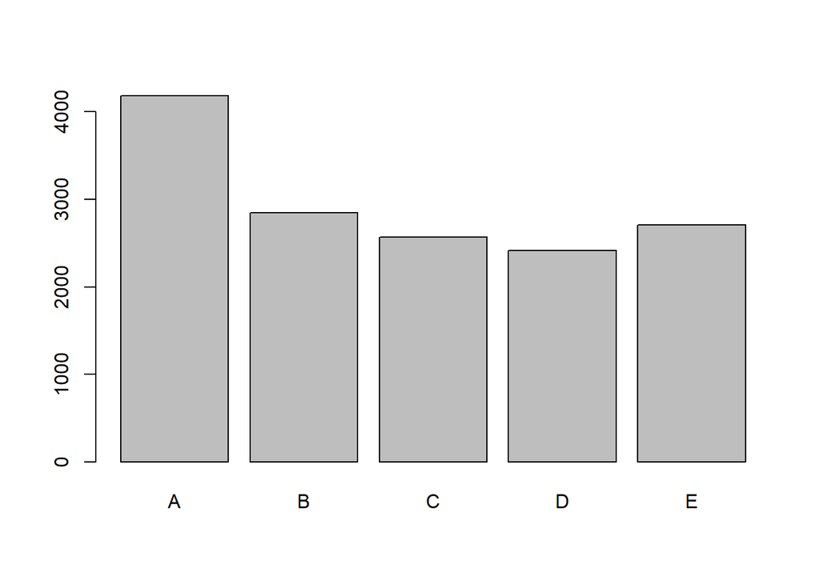

```r
barplot(table(subTraining$classe))
```

LEVEL A occurs most. D appears to be the least frequent one

## Prediction models

### Decision tree

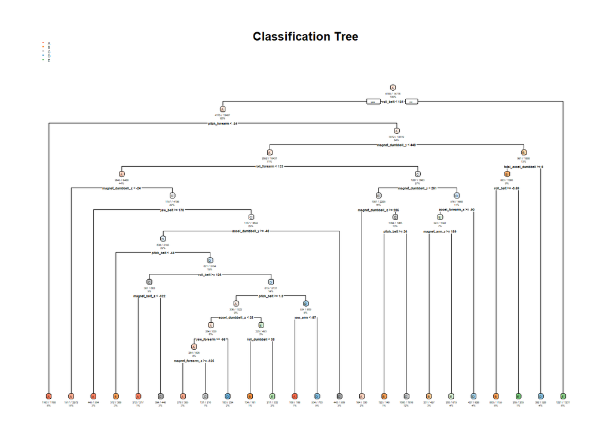

```r
# Model Fit
modFitDTree <- rpart(classe ~ ., data=subTraining, method="class")
# prediction
predictDTree <- predict(modFitDTree, subTesting, type = "class")
# Plot
rpart.plot(modFitDTree, main="Classification Tree", extra=102, under=TRUE, faclen=0)
```

```r
confusionMatrix(predictDTree, as.factor(subTesting$classe))
```

```
## Confusion Matrix and Statistics
##
##           Reference
## Prediction    A    B    C    D    E
##          A 1295  191   30   96   53
##          B   33  563   72   23   67
##          C   29   93  689  116   76
##          D   20   69   43  523   48
##          E   18   33   21   46  657
##
## Overall Statistics
##
##                Accuracy : 0.76
##                  95% CI : (0.7478, 0.7719)
##     No Information Rate : 0.2845
##     P-Value [Acc > NIR] : < 2.2e-16
##
##                   Kappa : 0.6944
##
##  Mcnemar's Test P-Value : < 2.2e-16
##
## Statistics by Class:
##
##                      Class: A Class: B Class: C Class: D Class: E
## Sensitivity            0.9283   0.5933   0.8058   0.6505   0.7292
## Specificity            0.8946   0.9507   0.9224   0.9561   0.9705
## Pos Pred Value         0.7778   0.7427   0.6869   0.7440   0.8477
## Neg Pred Value         0.9691   0.9069   0.9574   0.9331   0.9409
## Prevalence             0.2845   0.1935   0.1743   0.1639   0.1837
## Detection Rate         0.2641   0.1148   0.1405   0.1066   0.1340
## Detection Prevalence   0.3395   0.1546   0.2045   0.1434   0.1580
## Balanced Accuracy      0.9114   0.7720   0.8641   0.8033   0.8499
```

### Random forest

```r
modFitRForest <- randomForest(classe ~ ., data=subTraining, method="class")
predictRForest <- predict(modFitRForest, subTesting, type = "class")
```

```r
confusionMatrix(predictRForest, subTesting$classe)
```

```
## Confusion Matrix and Statistics
##
##           Reference
## Prediction    A    B    C    D    E
##          A 1393    4    0    0    0
##          B    2  945    3    0    0
##          C    0    0  852    5    0
##          D    0    0    0  799    4
##          E    0    0    0    0  897
##
## Overall Statistics
##
##                Accuracy : 0.9963
##                  95% CI : (0.9942, 0.9978)
##     No Information Rate : 0.2845
##     P-Value [Acc > NIR] : < 2.2e-16
##
##                   Kappa : 0.9954
##
##  Mcnemar's Test P-Value : NA
##
## Statistics by Class:
##
##                      Class: A Class: B Class: C Class: D Class: E
## Sensitivity            0.9986   0.9958   0.9965   0.9938   0.9956
## Specificity            0.9989   0.9987   0.9988   0.9990   1.0000
## Pos Pred Value         0.9971   0.9947   0.9942   0.9950   1.0000
## Neg Pred Value         0.9994   0.9990   0.9993   0.9988   0.9990
## Prevalence             0.2845   0.1935   0.1743   0.1639   0.1837
## Detection Rate         0.2841   0.1927   0.1737   0.1629   0.1829
## Detection Prevalence   0.2849   0.1937   0.1748   0.1637   0.1829
## Balanced Accuracy      0.9987   0.9973   0.9976   0.9964   0.9978
```

## Conclusion

Random Forest Algorithm had more than 99 precentage of accuracy.So, it is more enough to predict the final testing model.

```r
finalClassePRED <- predict(modFitRForest, testing)
print(finalClassePRED)
```

```
##  1  2  3  4  5  6  7  8  9 10 11 12 13 14 15 16 17 18 19 20
##  B  A  B  A  A  E  D  B  A  A  B  C  B  A  E  E  A  B  B  B
## Levels: A B C D E
```